# Feeding rate variability

Nima Moghaddas

2023-06-01

```r
library(malariasimulation)
library(lme4)
library(dplyr)
library(RColorBrewer)
```

We are interested to understand the variability in feeding rates over time, cluster and mosquito species. This will inform the level at which we include feeding rate in the final simulations. One way to do this is to compare fits for generalised linear mixed effects models with different fixed effects to understand which covariates significantly improve the model. Then we can include different random effects to understand what fraction of the variability is explained by each. First let’s look at the cluster level dyed fraction data for Zambia and Mali.

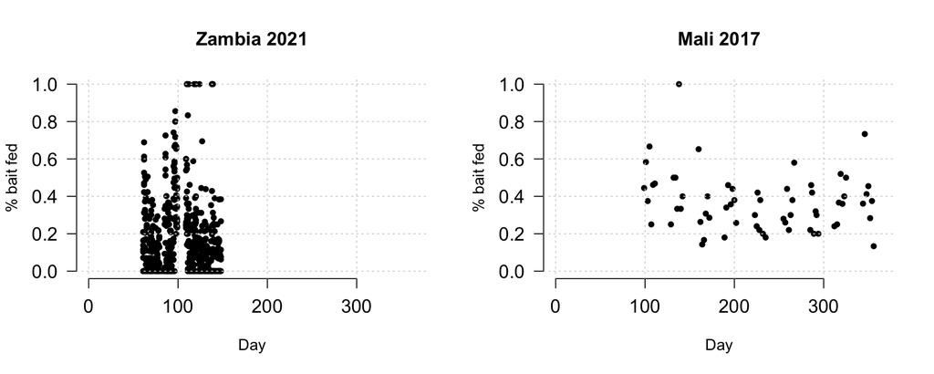

```r
par(las=1, mfrow=c(1,2))
# The Zambia trial has data for every mosquito caught so first we need to summarise across cluster and date
zambia |>
  group_by(collection_date, cluster) |>
  summarise(dyed_fraction = sum(positive)/n()) -> zambia_grouped
zambia_grouped$days <- (month(zambia_grouped$collection_date)-1)*30 + day(zambia_grouped$collection_date)
plot(zambia_grouped$days,
     zambia_grouped$dyed_fraction,
     cex=1.1, pch=20, frame.plot = F, xlab = "Day", ylab = "% bait fed",
     ylim = c(0,1), cex.axis=1.2, xlim = c(1,365))
grid()
title("Zambia 2021")
# The Mali trial only has data for total stained and unstained mosquitoes by village and date
plot(mali$days,
     mali$dyed_fraction,
     cex=1.1, pch=20, frame.plot = F, xlab = "Day", ylab = "% bait fed",
     ylim = c(0,1), cex.axis=1.2, xlim = c(1,365))
grid()
title("Mali 2017")
```

As you can see, data was collected much more frequently in Zambia than Mali. In fact the Zambia data has information about every mosquito that was caught and whether it was bait fed. Whereas the Mali data only contains summary data for the total number of mosquitoes that were bait fed out of the total sample that was tested. However, the Mali data was collected over a longer period.

Lets look at the data grouped by cluster averaged over different time periods.

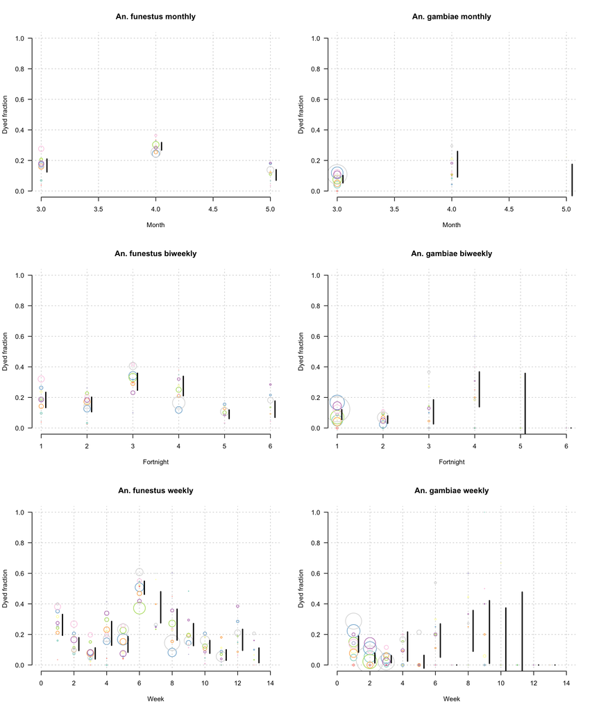

Clearly, there is variability from week to week and month to month. But also there is considerable variability between clusters at the same timepoint. It may be worth estimating feeding rates at the level of the cluster.

We want to obtain cluster level estimates for the feeding rate at different time points throughout the season and their associated uncertainties. Firstly let’s see if including cluster as a fixed effect is justified. Here we use the drop1 function which tests the significance of removing each of the fixed effects from the model in one go.

```r
zambia$month_caught <- factor(zambia$month_caught)
zambia$half_month <- factor(zambia$half_month)
zambia$week <- factor(zambia$week)
zambia$mosquito_species <- factor(zambia$mosquito_species)
fit1 <- glmer(
  positive ~ cluster + month_caught + mosquito_species + (1|days),
  data = zambia, family = "binomial", control = glmerControl(optimizer = "bobyqa")
)
fit2 <- glmer(
  positive ~ cluster + half_month + mosquito_species + (1|days),
  data = zambia, family = "binomial", control = glmerControl(optimizer = "bobyqa")
)
fit3 <- glmer(
  positive ~ cluster + week + mosquito_species + (1|days),
  data = zambia, family = "binomial", control = glmerControl(optimizer = "bobyqa")
)

drop1(fit1, test = "Chisq")
```

```
## Single term deletions
##
## Model:
## positive ~ cluster + month_caught + mosquito_species + (1 | days)
##                  npar   AIC     LRT   Pr(Chi)
## <none>                38344
## cluster             9 38485 159.325 < 2.2e-16 ***
## month_caught        2 38372  31.628 1.355e-07 ***
## mosquito_species    1 38453 111.284 < 2.2e-16 ***
## ---
## Signif. codes:  0 '***' 0.001 '**' 0.01 '*' 0.05 '.' 0.1 ' ' 1
```

```r
drop1(fit2, test = "Chisq")
```

```
## Single term deletions
##
## Model:
## positive ~ cluster + half_month + mosquito_species + (1 | days)
##                  npar   AIC     LRT   Pr(Chi)
## <none>                38365
## cluster             9 38508 160.789 < 2.2e-16 ***
## half_month          5 38372  16.224  0.006234 **
## mosquito_species    1 38474 110.455 < 2.2e-16 ***
## ---
## Signif. codes:  0 '***' 0.001 '**' 0.01 '*' 0.05 '.' 0.1 ' ' 1
```

```r
drop1(fit3, test = "Chisq")
```

```
## Single term deletions
##
## Model:
## positive ~ cluster + week + mosquito_species + (1 | days)
##                  npar   AIC     LRT   Pr(Chi)
## <none>                38354
## cluster             9 38497 160.927 < 2.2e-16 ***
## week               12 38372  41.384 4.226e-05 ***
## mosquito_species    1 38463 110.710 < 2.2e-16 ***
## ---
## Signif. codes:  0 '***' 0.001 '**' 0.01 '*' 0.05 '.' 0.1 ' ' 1
```

Adding cluster significantly improved the model fit at all three levels: monthly, biweekly and weekly.

We can fit a GLMM with random effects on cluster and day to see what fraction of the variance is explained by cluster.

```r
fit4 <- glmer(
  positive ~ (1|cluster) + month_caught + mosquito_species + (1|days),
  data = zambia, family = "binomial", control = glmerControl(optimizer = "bobyqa")
)
fit5 <- glmer(
  positive ~ (1|cluster) + half_month + mosquito_species + (1|days),
  data = zambia, family = "binomial", control = glmerControl(optimizer = "bobyqa")
)
fit6 <- glmer(
  positive ~ (1|cluster) + week + mosquito_species + (1|days),
  data = zambia, family = "binomial", control = glmerControl(optimizer = "bobyqa")
)
VarCorr(fit4)
```

```
##  Groups  Name        Std.Dev.
##  days    (Intercept) 0.96784
##  cluster (Intercept) 0.23582
```

```r
VarCorr(fit5)
```

```
##  Groups  Name        Std.Dev.
##  days    (Intercept) 0.76257
##  cluster (Intercept) 0.23393
```

```r
VarCorr(fit6)
```

```
##  Groups  Name        Std.Dev.
##  days    (Intercept) 0.60879
##  cluster (Intercept) 0.23246
```

The random effect variance for days is greater than the cluster variance suggesting the bait feeding rate consistently varies more over time than between clusters.

```r
# fit1 <- glmer(
#   positive ~ week + (1|days) + (1|cluster) -1,
#   data = zambia, family = "binomial", control = glmerControl(optimizer = "bobyqa")
# )
# summary(fit1)
# estimates.bias <-
#   cbind(fixef(fit1),
#         confint(fit1, method = "Wald")[2:23,]
#         )
# estimates <-
#   jensen.logit.adjust(p = plogis(estimates.bias), V = sum(unlist(VarCorr(fit1))))
```

Here are the results for Mali.

```r
mali$Village <- factor(mali$Village)
fit3 <-
  glmer(
    cbind(total_asb_positive, total_sampled-total_asb_positive) ~
      (1|Village) + (1|days),
    family = "binomial", data = mali,
    control = glmerControl(optimizer = "bobyqa"))
summary(fit3)
```

```
## Generalized linear mixed model fit by maximum likelihood (Laplace
##   Approximation) [glmerMod]
##  Family: binomial  ( logit )
## Formula: cbind(total_asb_positive, total_sampled - total_asb_positive) ~
##     (1 | Village) + (1 | days)
##    Data: mali
## Control: glmerControl(optimizer = "bobyqa")
##
##      AIC      BIC   logLik deviance df.resid
##    341.9    348.3   -168.0    335.9       60
##
## Scaled residuals:
##     Min      1Q  Median      3Q     Max
## -1.4757 -0.4735  0.1146  0.4943  2.2458
##
## Random effects:
##  Groups  Name        Variance Std.Dev.
##  days    (Intercept) 0.15831  0.3979
##  Village (Intercept) 0.01186  0.1089
## Number of obs: 63, groups:  days, 63; Village, 7
##
## Fixed effects:
##             Estimate Std. Error z value Pr(>|z|)
## (Intercept) -0.65276    0.08327  -7.839 4.53e-15 ***
## ---
## Signif. codes:  0 '***' 0.001 '**' 0.01 '*' 0.05 '.' 0.1 ' ' 1
```

There is much less variance in the Mali data but still we see the variance in time is greater than the variance between villages.